# Red Wine Quality Check By Himanshu Suneja

> In this project, I will explore the data set of RedWine. This data set contains 1599 red wines with 11 variables. Our objective will be to check how chemicals influence the quality of wines.

```
## 'data.frame':    1599 obs. of  13 variables:
##  $ X                   : int  1 2 3 4 5 6 7 8 9 10 ...
##  $ fixed.acidity       : num  7.4 7.8 7.8 11.2 7.4 7.4 7.9 7.3 7.8 7.5 ...
##  $ volatile.acidity    : num  0.7 0.88 0.76 0.28 0.7 0.66 0.6 0.65 0.58 0.5 ...
##  $ citric.acid         : num  0 0 0.04 0.56 0 0 0.06 0 0.02 0.36 ...
##  $ residual.sugar      : num  1.9 2.6 2.3 1.9 1.9 1.8 1.6 1.2 2 6.1 ...
##  $ chlorides           : num  0.076 0.098 0.092 0.075 0.076 0.075 0.069 0.065 0.073 0.071 ...
##  $ free.sulfur.dioxide : num  11 25 15 17 11 13 15 15 9 17 ...
##  $ total.sulfur.dioxide: num  34 67 54 60 34 40 59 21 18 102 ...
##  $ density             : num  0.998 0.997 0.997 0.998 0.998 ...
##  $ pH                  : num  3.51 3.2 3.26 3.16 3.51 3.51 3.3 3.39 3.36 3.35 ...
##  $ sulphates           : num  0.56 0.68 0.65 0.58 0.56 0.56 0.46 0.47 0.57 0.8 ...
##  $ alcohol             : num  9.4 9.8 9.8 9.8 9.4 9.4 9.4 10 9.5 10.5 ...
##  $ quality             : int  5 5 5 6 5 5 5 7 7 5 ...
```

```
##    Min. 1st Qu.  Median    Mean 3rd Qu.    Max.
##   3.000   5.000   6.000   5.636   6.000   8.000
```

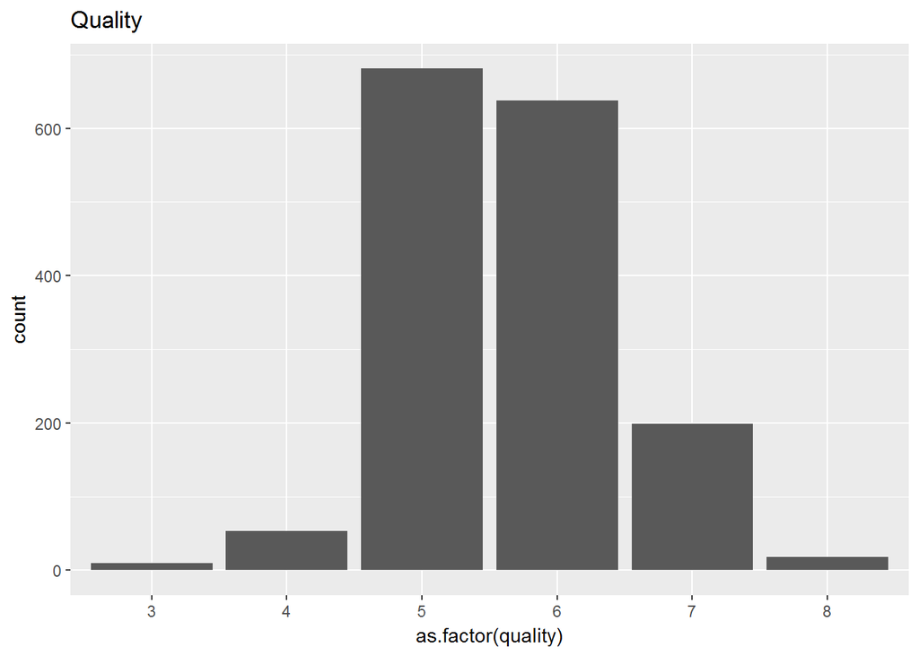

```
## $x
## [1] "Quality"
##
## attr(,"class")
## [1] "labels"
```

# Univariate Plots Section

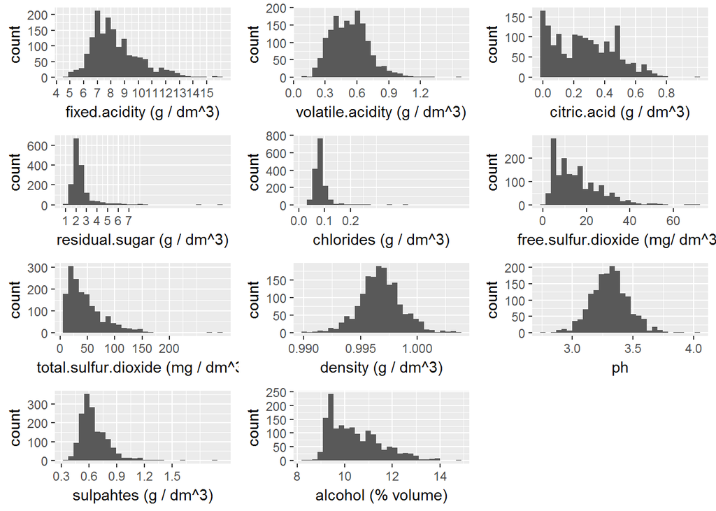

# Univariate Analysis

We can clearly see that the quality of wine ranges from 3 to 8 where 5 and 6 are the most common values and 3, 4, 7, 8 are least comm. Thus form this, we can create a variable ‘rating’ to rate this data.Ther are many variables with extreem ouliers.We will investigate them later in our project

0-4: ‘poor’ 5-6: ‘good’ 7-8: ‘ideal’

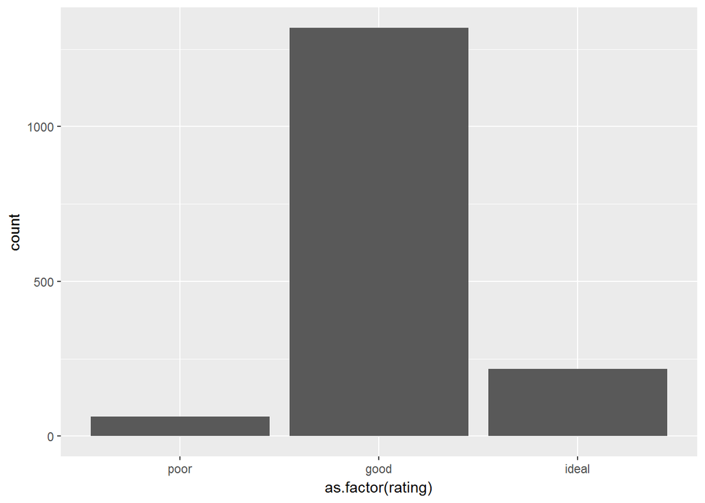

### Summary of ‘rating’

```
##  poor  good ideal
##    63  1319   217
```

### Total Acidity

Creating a new variable ‘Total Acidity’ to calculate the sum of all acie in wine

```
## [1]  8.10  8.68  8.60 12.04  8.10  8.06
```

### Outliers

fixed.acidity, volatile.acidity, sulfur.dioxide(free and total), sulphated and alcohol are having big ouliers. Lets plot base 10 graph of them

#### Summaries

Before plotting these graphs, we should better to look at thier summaries for better plotting

```
##    Min. 1st Qu.  Median    Mean 3rd Qu.    Max.
##    4.60    7.10    7.90    8.32    9.20   15.90
```

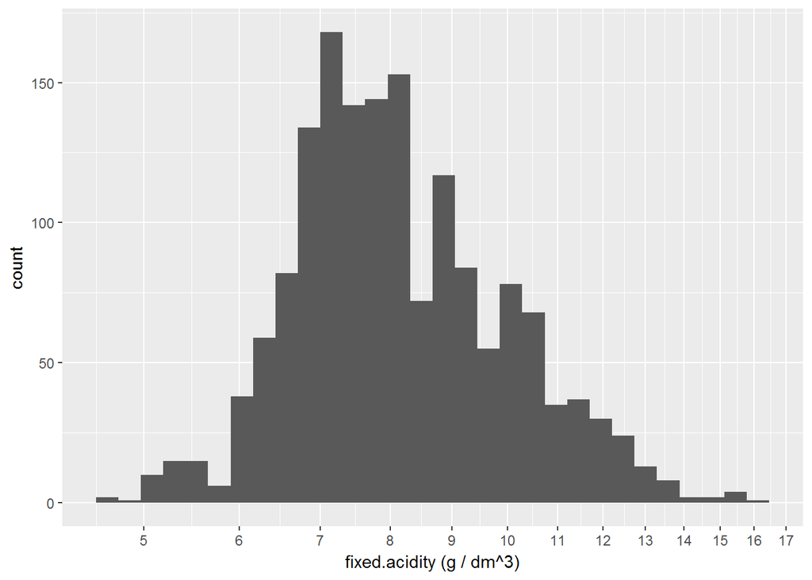

The above histogram is partially noramlly distributed with few ouliers.

```
##    Min. 1st Qu.  Median    Mean 3rd Qu.    Max.
##  0.1200  0.3900  0.5200  0.5278  0.6400  1.5800
```

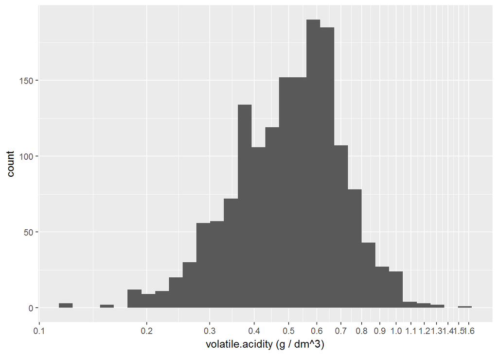

This graph has left skewed distribution.We can see some extreem outliers ranging between 0.1-0.2

```
##    Min. 1st Qu.  Median    Mean 3rd Qu.    Max.
##    1.00    7.00   14.00   15.87   21.00   72.00
```

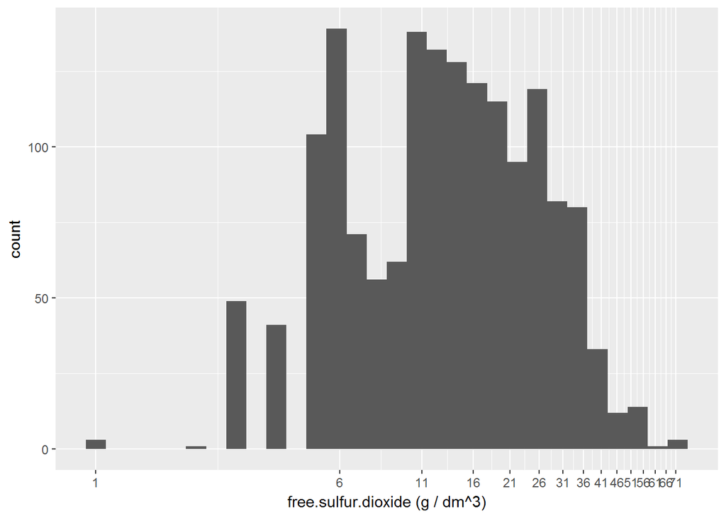

The above graph shows some loud distribution. It has very extreem outliers ranging 1-5.

```
##    Min. 1st Qu.  Median    Mean 3rd Qu.    Max.
##    6.00   22.00   38.00   46.47   62.00  289.00
```

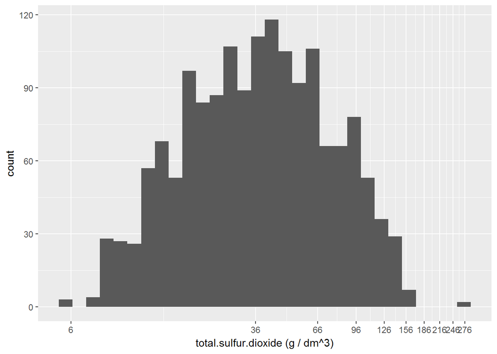

This above graph is quite normallly ditsributed but does has some outliers

```
##    Min. 1st Qu.  Median    Mean 3rd Qu.    Max.
##  0.3300  0.5500  0.6200  0.6581  0.7300  2.0000
```

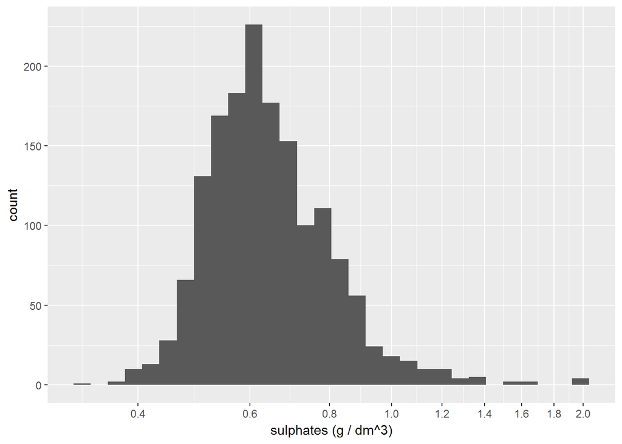

Though the above graph quite normall distributed but there are some big outliers at the end.

```
##    Min. 1st Qu.  Median    Mean 3rd Qu.    Max.
##    8.40    9.50   10.20   10.42   11.10   14.90
```

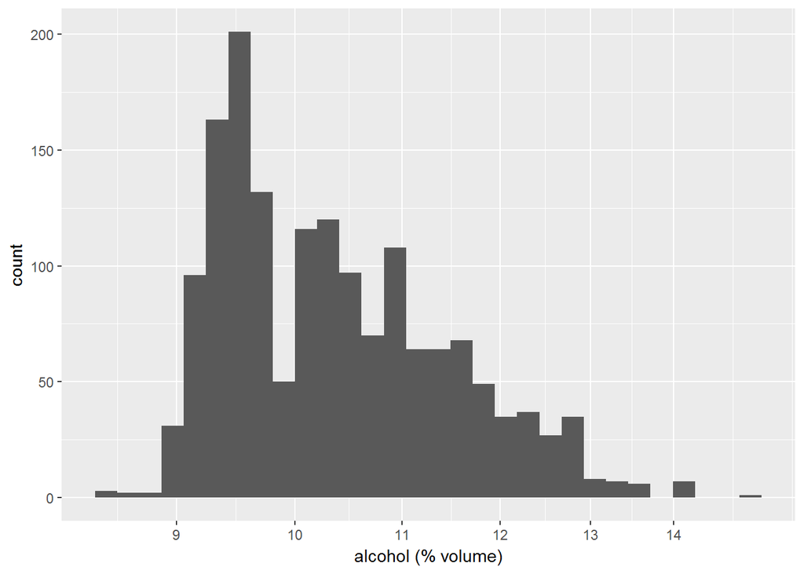

We can see that its is very much right skewed distribution.

### Citric.acid

After looking at the documentation, its found that there are many zeroes in citric acid. Lets count them.

```
## [1] 132
```

We found 132 zero values

### Looking into residual.sugar and chlorides

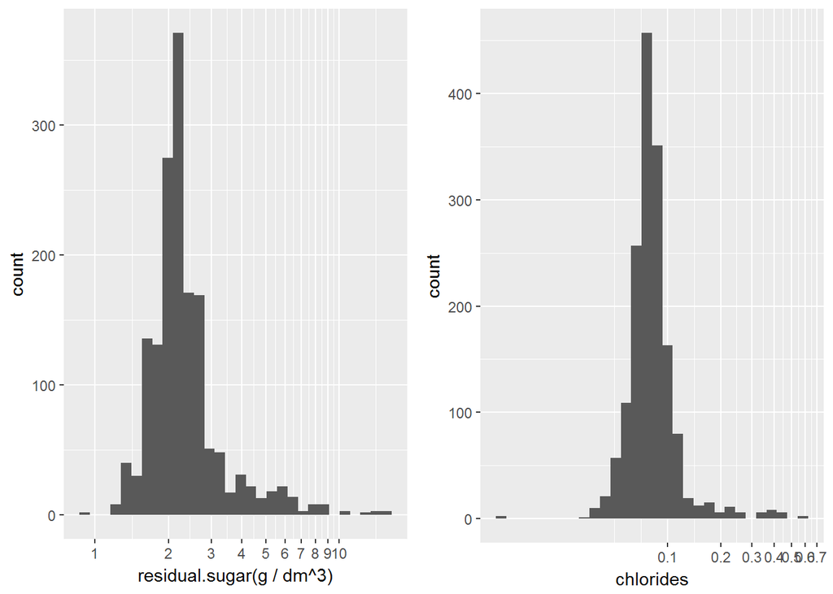

We can see there are extreem ouliers in the both data structure.

### Removing extreem outliers

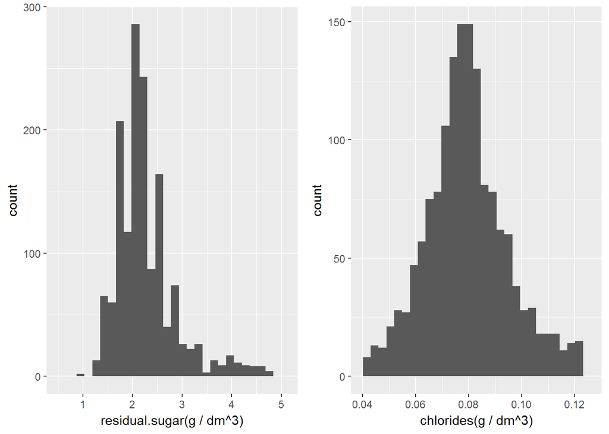

Thus after removing outliers, we saw that chlorides had normal distribution.

### What is the structure of your dataset?

```
## 'data.frame':    1599 obs. of  14 variables:
##  $ X                   : int  1 2 3 4 5 6 7 8 9 10 ...
##  $ fixed.acidity       : num  7.4 7.8 7.8 11.2 7.4 7.4 7.9 7.3 7.8 7.5 ...
##  $ volatile.acidity    : num  0.7 0.88 0.76 0.28 0.7 0.66 0.6 0.65 0.58 0.5 ...
##  $ citric.acid         : num  0 0 0.04 0.56 0 0 0.06 0 0.02 0.36 ...
##  $ residual.sugar      : num  1.9 2.6 2.3 1.9 1.9 1.8 1.6 1.2 2 6.1 ...
##  $ chlorides           : num  0.076 0.098 0.092 0.075 0.076 0.075 0.069 0.065 0.073 0.071 ...
##  $ free.sulfur.dioxide : num  11 25 15 17 11 13 15 15 9 17 ...
##  $ total.sulfur.dioxide: num  34 67 54 60 34 40 59 21 18 102 ...
##  $ density             : num  0.998 0.997 0.997 0.998 0.998 ...
##  $ pH                  : num  3.51 3.2 3.26 3.16 3.51 3.51 3.3 3.39 3.36 3.35 ...
##  $ sulphates           : num  0.56 0.68 0.65 0.58 0.56 0.56 0.46 0.47 0.57 0.8 ...
##  $ alcohol             : num  9.4 9.8 9.8 9.8 9.4 9.4 9.4 10 9.5 10.5 ...
##  $ quality             : int  5 5 5 6 5 5 5 7 7 5 ...
##  $ rating              : Ord.factor w/ 3 levels "poor"<"good"<..: 2 2 2 2 2 2 2 3 3 2 ...
```

### What is/are the main feature(s) of interest in your dataset?

The quaity of wine is the main feature of interest.

### What other features in the dataset do you think will help support your investigation into your feature(s) of interest?

Density and ph are highly normally distributed, thus they can help in investigation

### Did you create any new variables from existing variables in the dataset?

I created two new variables:

Rating = to rate the variabes as ‘poor’, ‘good’, ‘ideal’ toatal.acidity = to summ up the total acidity of wine

### Of the features you investigated, were there any unusual distributions? Did you perform any operations on the data to tidy, adjust, or change the form of the data? If so, why did you do this?

Residual.sugar and chlorides contains many outliers but after doing some operations, chlorides get into normal distribution.

citric.acid have 132 zero values but after reading documentation it totally justify our investigation.

# Bivariate Plots Section

### Boxplots of quality

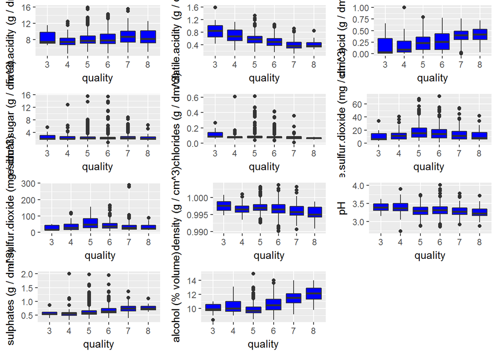

The above plots determines the quality of wine through various varibales in our dataset.

### Boxplots Of Rating

#### Plotting Boxplots and thier correlations against quality.

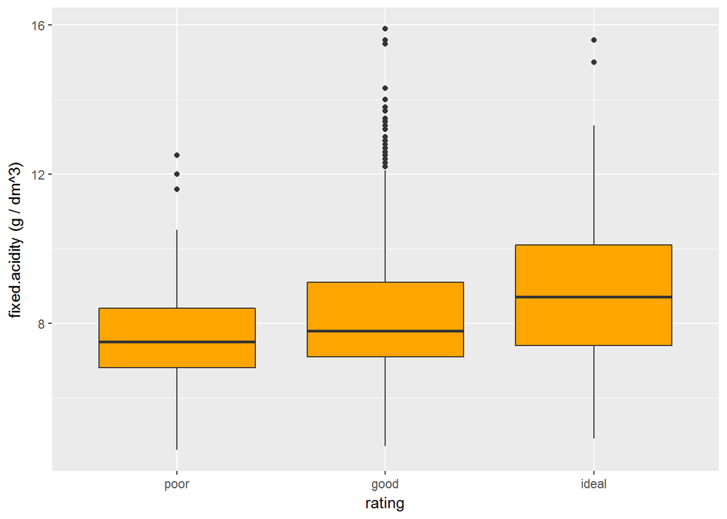

```
##       cor
## 0.1240516
```

The above plot shows the increase in the “quality” rating of as the “fixed acidity” content increases.

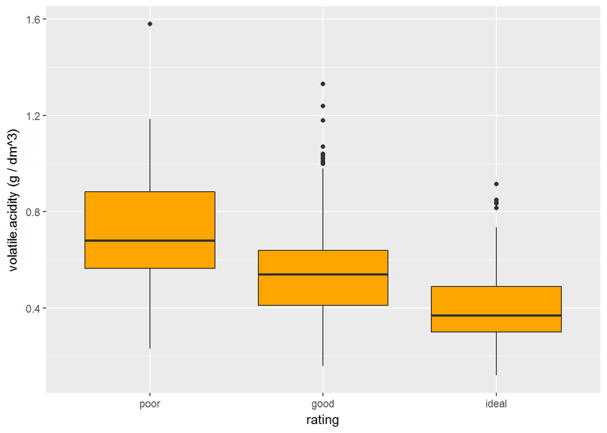

```
##        cor
## -0.3905578
```

We can see the inverse effect in the “quality” rating as the “volatile acidity” content increases.

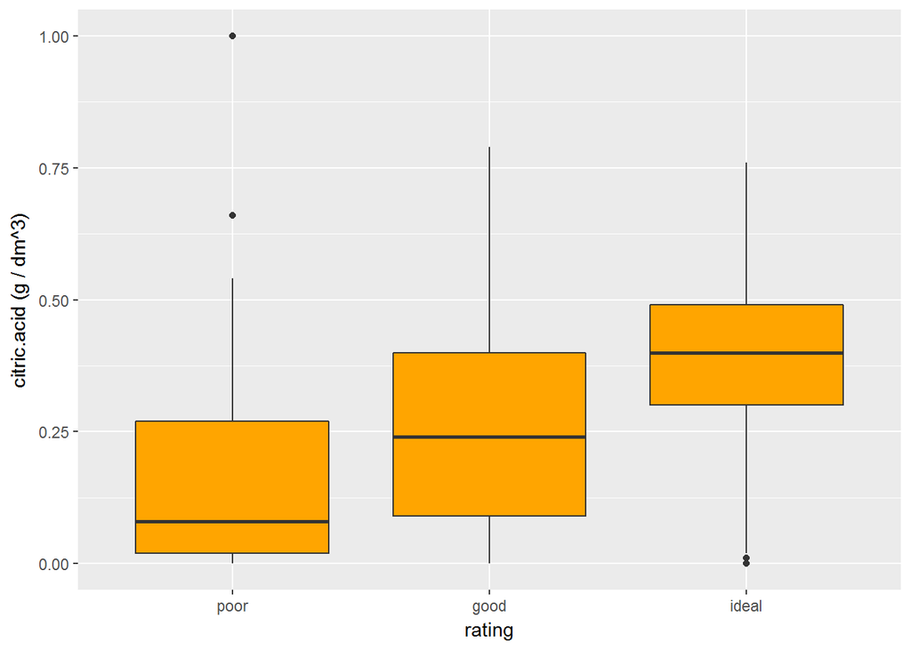

```
##       cor
## 0.2263725
```

From the chart we can see that the “quality” rating increase as the “citric acid” content increase. Thus “citric acid” content need to be on the higher side for healthy “quality” rating.

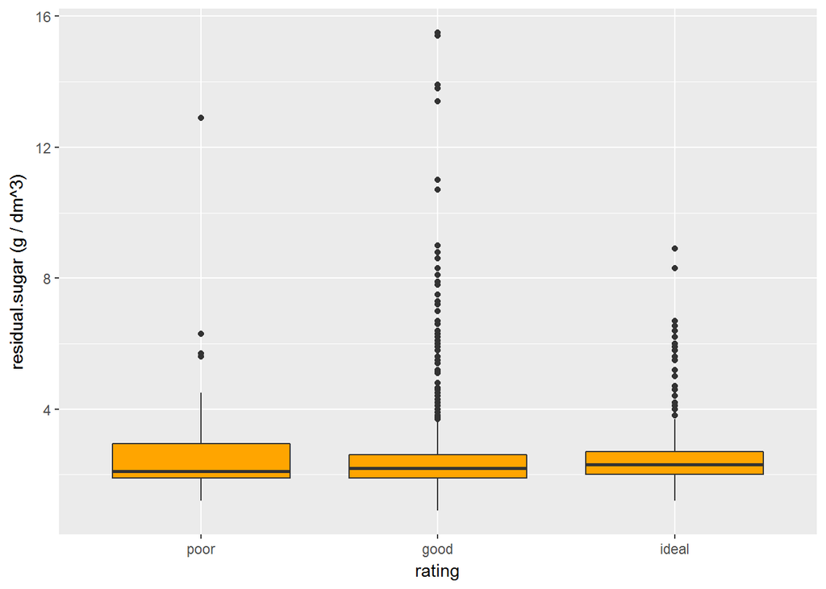

```
##        cor
## 0.01373164
```

Although there isn’t much effct of “residual sugar” content in the rating, but we can see see big outliers in good rating.

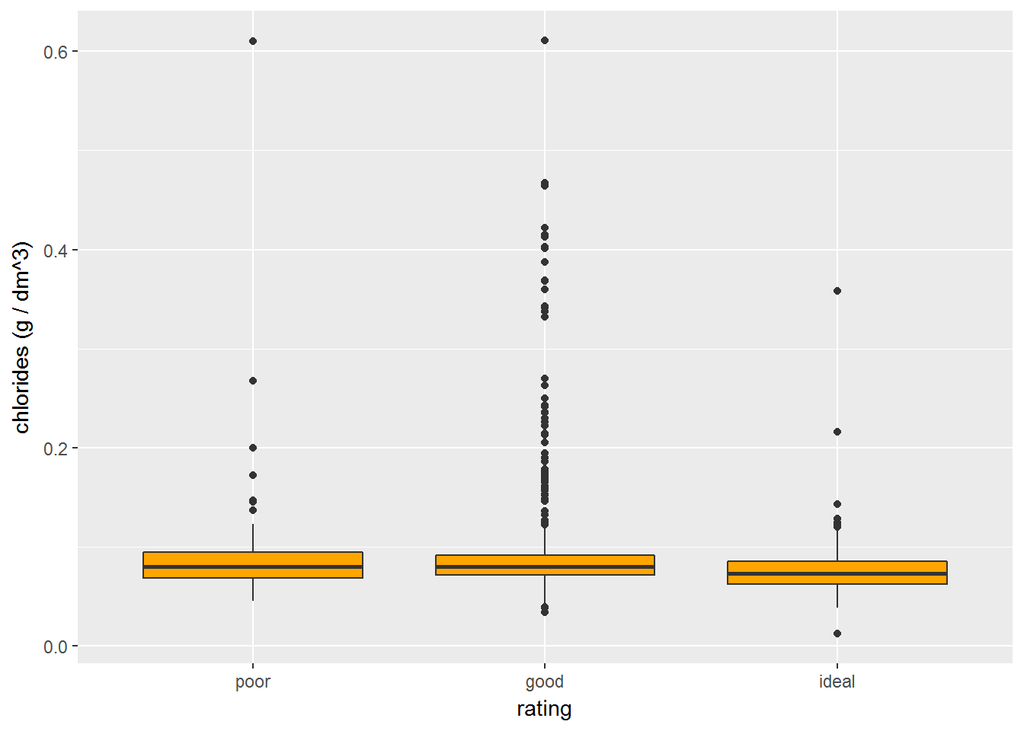

```
##        cor
## -0.1289066
```

We can see the content of “chlorides”" has very less effect on the “quality” rating of the wine.

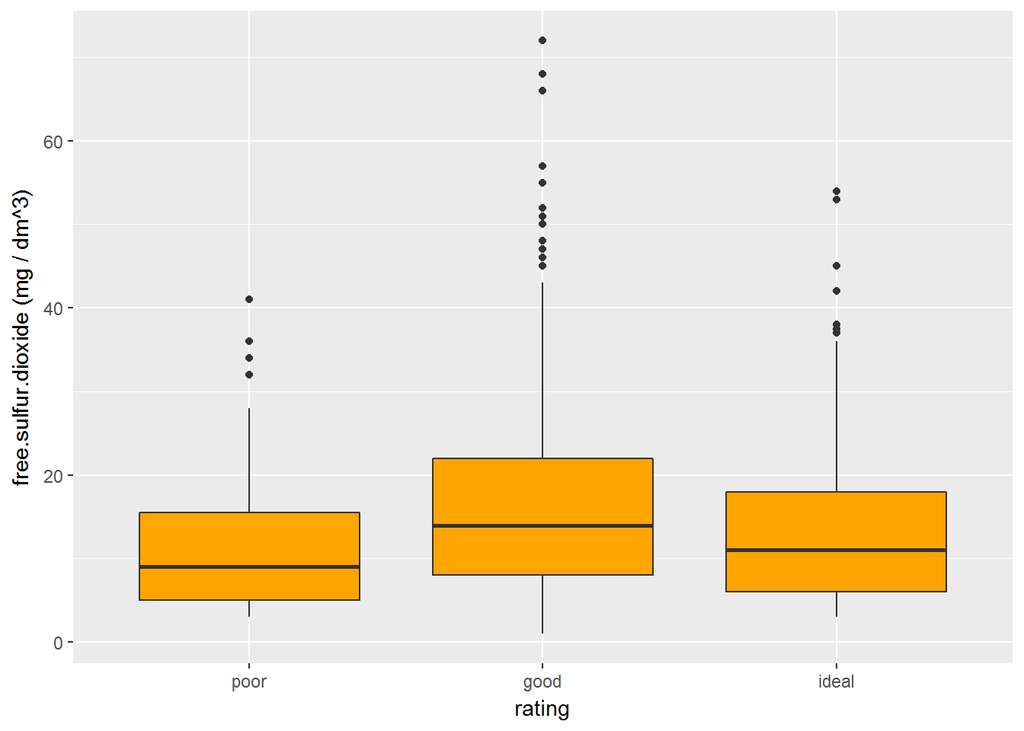

```
##         cor
## -0.05065606
```

We can see that at certain range of “Free sulfur dixide” content, the “quality” rating has been good, but when the content increases from that range its shows inverse effect.

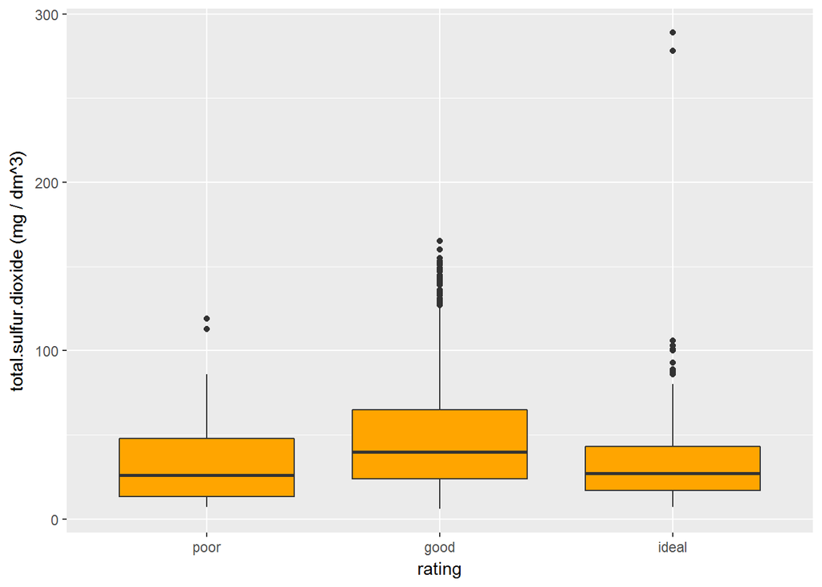

```
##        cor
## -0.1851003
```

Although, the “total sulfur dioxide” content has a very less effect on the “quality” rating, but we can see a dip in the rating as the content increases.

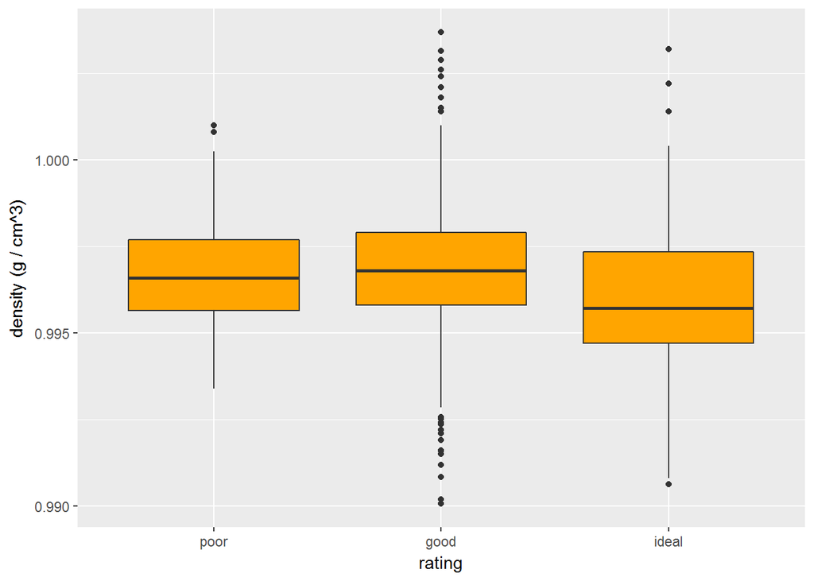

```
##        cor
## -0.1749192
```

Although “density has good impact on”quality“” of wine, but we can see that the rating almost remains the same.

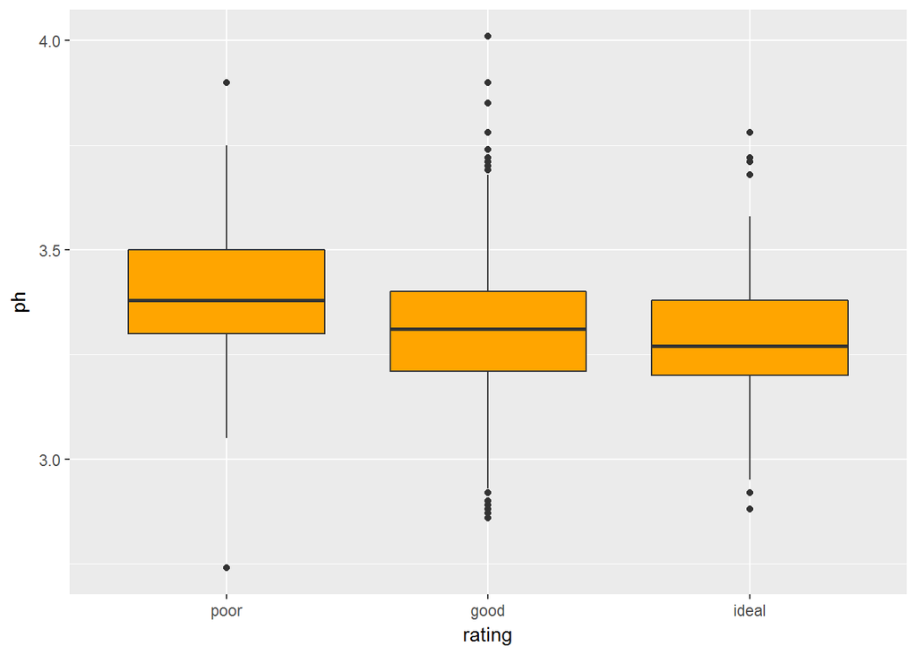

```
##         cor
## -0.05773139
```

We can see a little dip the “quality” rating of wine as the “ph” content increases.

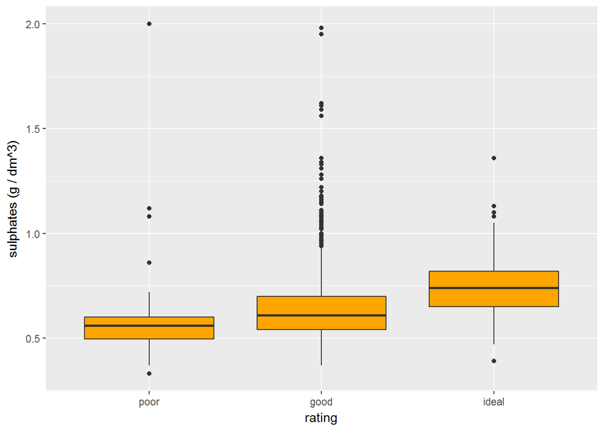

```
##       cor
## 0.2513971
```

There is a positive proportional relationship between content of “sulphates”" and the “quality” rating of the wine.

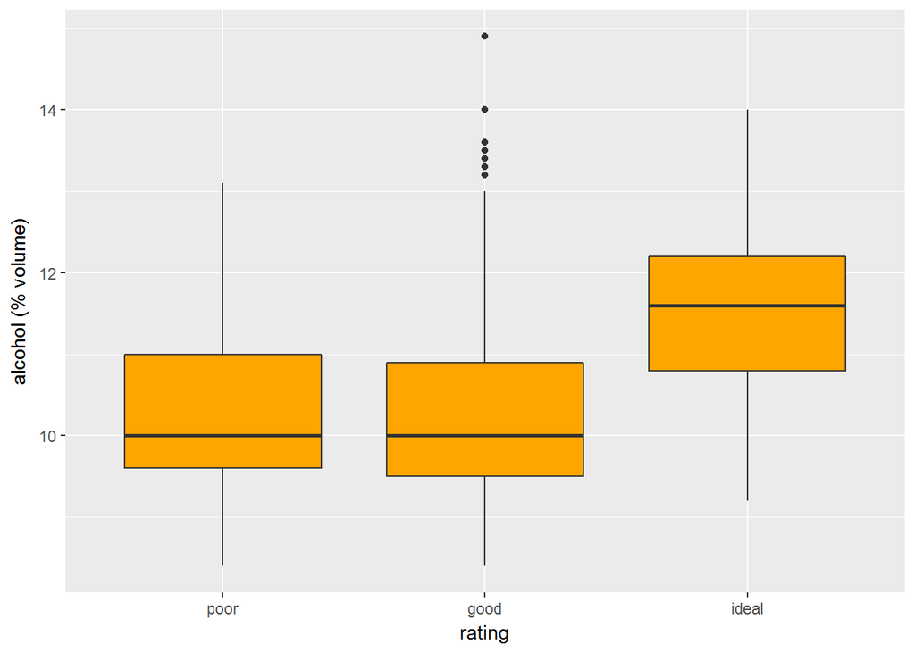

```
##       cor
## 0.4761663
```

There is a huge jump in the graph as the content of “alcohol”" increases.This shows the influence of alcohol in the “quality” rating of the wine.

### Means of variabler where rating = ‘ideal’

```
##        fixed.acidity     volatile.acidity          citric.acid
##           8.84700461           0.40552995           0.37649770
##       residual.sugar            chlorides  free.sulfur.dioxide
##           2.70875576           0.07591244          13.98156682
## total.sulfur.dioxide              density                   pH
##          34.88940092           0.99603028           3.28880184
##            sulphates              alcohol        total.acidity
##           0.74345622          11.51804916                   NA
```

# Bivariate Analysis

### Talk about some of the relationships you observed in this part

#### Poor Rating

lower ‘sulfur.dioxide’ and ‘sulphates’ higher ‘pH’ and high ‘density’

#### Good Rating

low fixed.acidity and volatile.acidity higher sulfur.dioxide

#### Ideal Rating

higher fixed.acidity , lower volatile.acidity and higher citric.acid lower pH and density

### Did you observe any interesting relationships between the other features

#### Some Relationship between variables and the variable ‘Total.Acidity’.

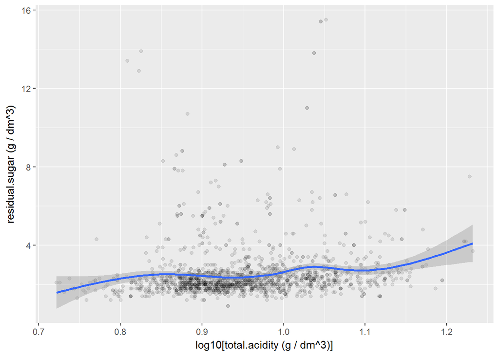

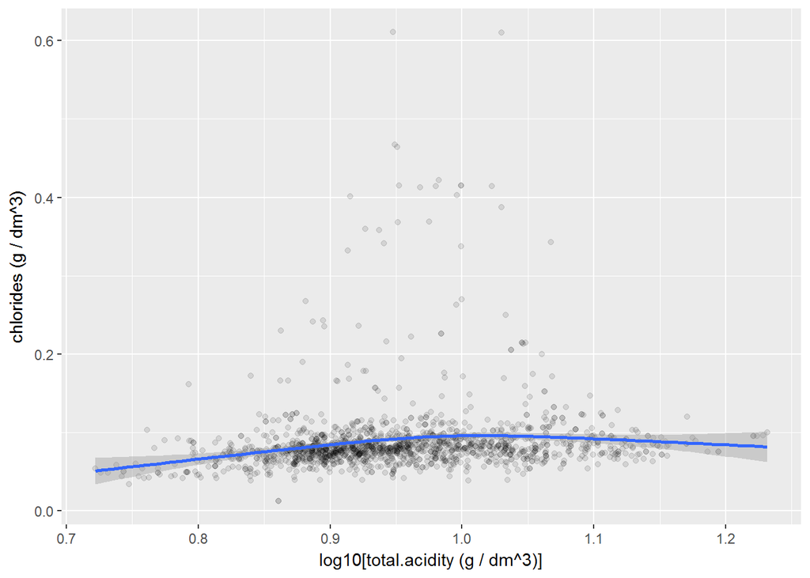

We see that there is approx constant relationship between residual.sugar and log10(Total.Acidity), and chlorides and log10(Total.acidity)

### What was the strongest relationship you found?

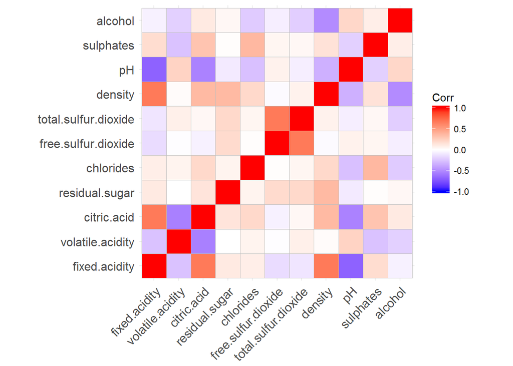

# Multivariate Plots Section

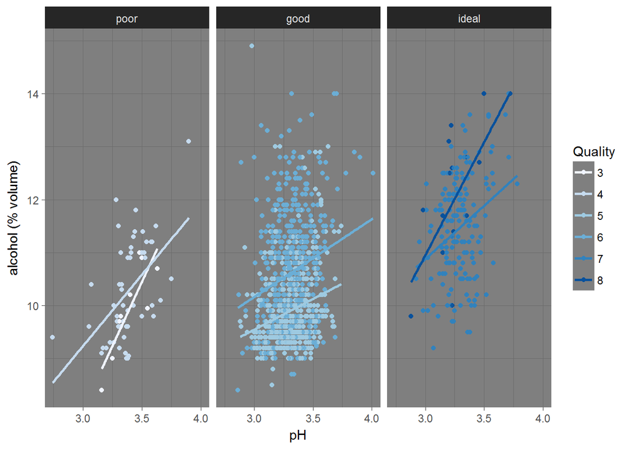

The above plot depict that lower ph content with higher alcohol yields better rating.

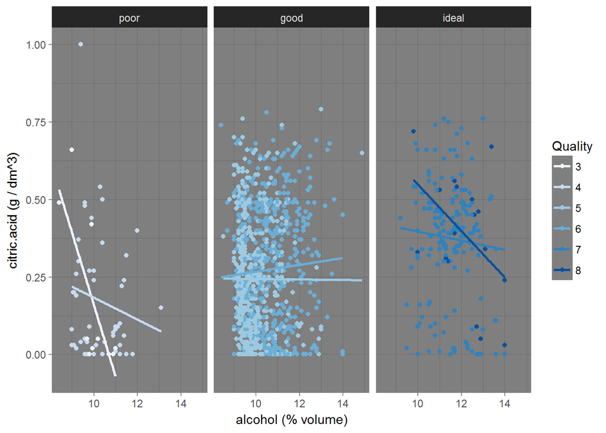

We an see that higher content of citric acid with alcohol have better results. Higher citric acids yields better wine.

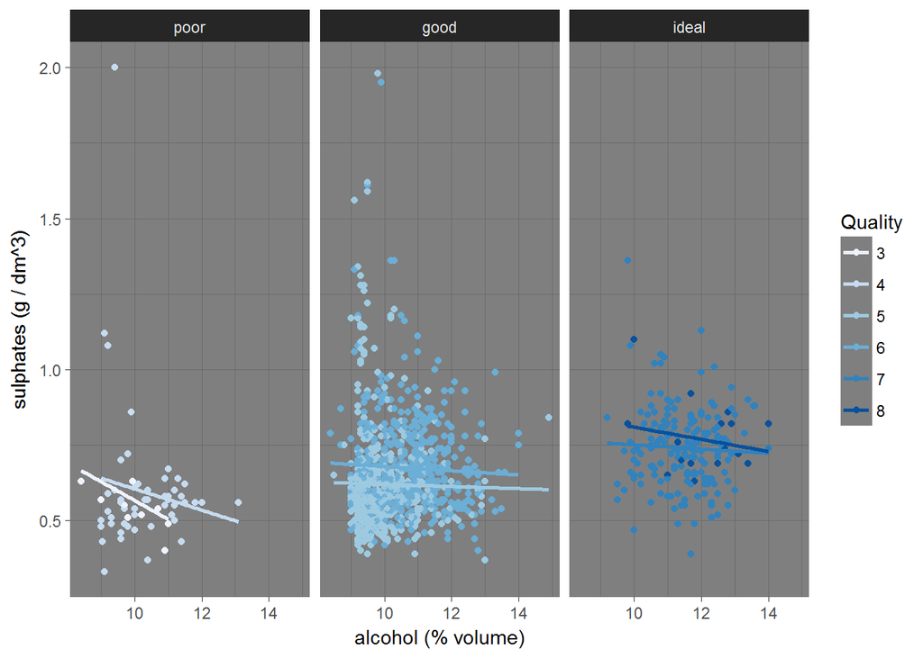

The sulphate content on the higher side has better rating then that of on lower side.

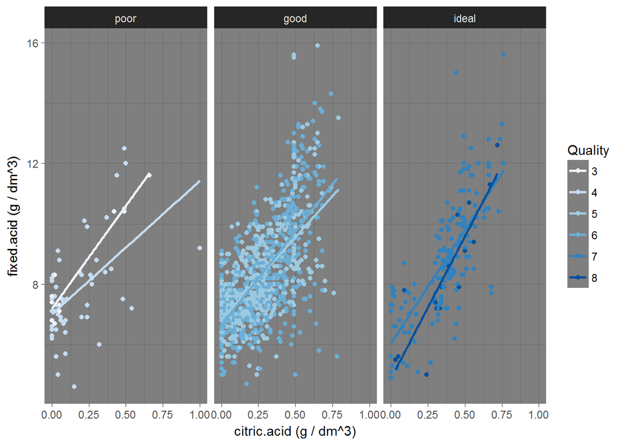

# Multivariate Analysis

# Final Plots and Summary

### Plot One: Alcohol effect on quality

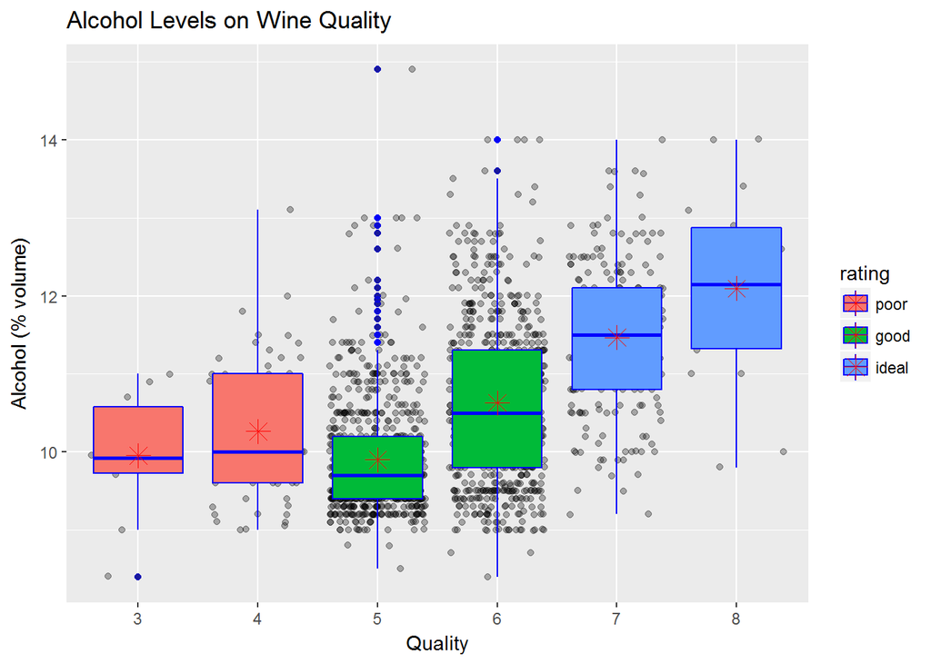

### Description One

Since alcohol is the most basic part of wine, its investigation is must. It is clearly seen that higer the alcohol content yields better wine quality

### Plot Two: Acid effect on quality

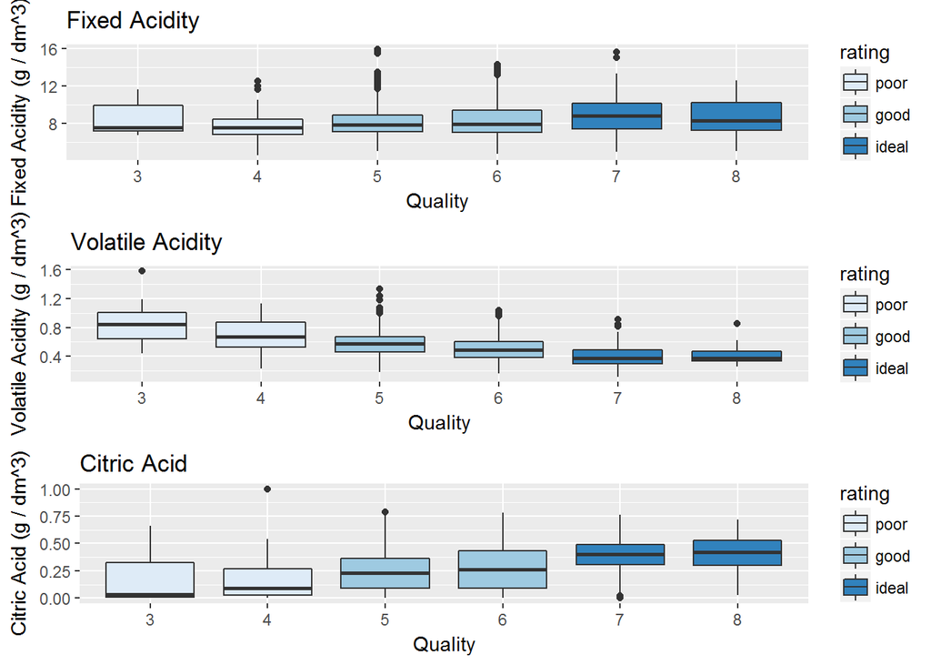

### Description Two

A wine always contains some acids in it.The more, the better. From above plot, as the citric.acid increases, the quality also increases.Same can be said for fixed.acidity.Volatile.acidity has inverse impact on wine quality.

### Plot Three

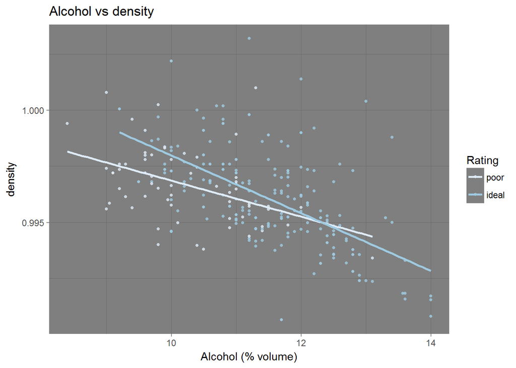

### Description Three

Always good to check the patterns between poor and ideal wines through different variables.Above plot differentiate between good and bad wines. It shows higher the % of alcohol and lesser the density give better wines.

# Reflection

Thus, we found many differerent qualitiy dependencies of wine. We did lot of plotting to spot relatonship between different variables

Also i found that in residual.sugar and chlorides contains many outlier.When removed out outliers, i found there were still many outliers in residual.sugar . More research work is needed to find out residual.sugar ideal wine quality